# Zoé’s solution for Mihai’s Project

```r
#libraries
library(tidyverse)
```

*ISSUE:* **Here I am not sure how to get only one variable per plant to be able to draw the bar plot.**

| Plant | Type | Treatment | mean_uptake |
| --- | --- | --- | --- |
| Qn1 | Quebec | nonchilled | 33.22857 |
| Qn1 | Quebec | nonchilled | 33.22857 |
| Qn1 | Quebec | nonchilled | 33.22857 |
| Qn1 | Quebec | nonchilled | 33.22857 |
| Qn1 | Quebec | nonchilled | 33.22857 |
| Qn1 | Quebec | nonchilled | 33.22857 |
| Qn1 | Quebec | nonchilled | 33.22857 |
| Qn2 | Quebec | nonchilled | 35.15714 |
| Qn2 | Quebec | nonchilled | 35.15714 |
| Qn2 | Quebec | nonchilled | 35.15714 |

[output cut: 74 more lines]

Line plots for each plant’s CO2 uptake over the conc condition (x-Axis) for all plants from Quebec. These line plots should be plottet in a 2 x 4 grid, where on the first row you have line plots of all chilled plants (3) + the mean chilled CO2 uptake by conc, and on the second row the same for the nonchilled plants

*ISSUE:* **Unsure how to add a plot with the mean data here…Further, facet seems to scramble the plots?**

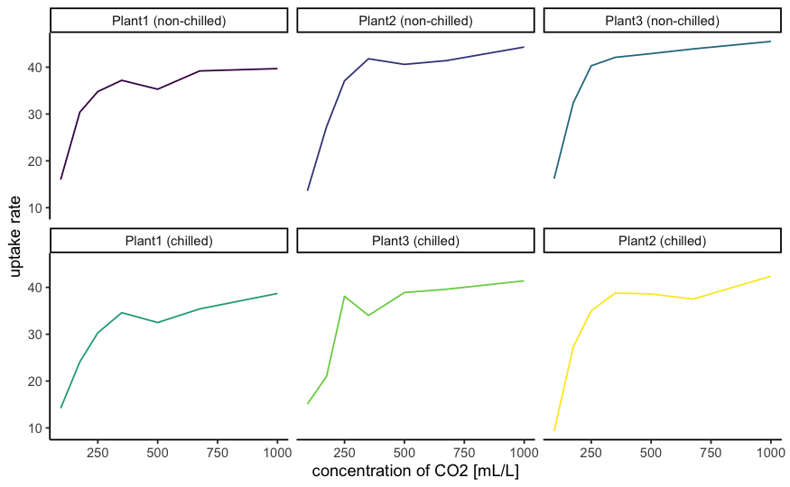

##Hypotheses - chilled plants can take up less oxygen in any CO2 concentrations - Plant 3 is most affect by chilling - Plant 3 is also the most able to take up CO2

##Statistics I have no idea how to approach hypothesis testing here - maybe a hint for which package to look at would be good? Thanks!

##Visualisation Here I am also unsure what kind of visualisation you were thinking of, maybe you can help.